# Klimatický rozvrat a média veřejné služby

Climate breakdown and public service media — Česká televize 2012–2022

**Výzkumný tým:** Andrea Culková (PI), Michal Škop (analýza dat) | **Instituce:** FAMU | **Korpus:** 2 914 dokumentů z celkových 531 593 přepisů zpravodajství ČT

## O výzkumu

Výzkumný projekt analyzuje, jak Česká televize pokrývala klimatickou změnu v letech 2012–2022. Pomocí korpusové analýzy, strojového učení a kvalitativní diskurzivní analýzy jsme zkoumali geografické pokrytí, hlasy mluvčích, postoje (stanoviska) a témata v 2 914 klimaticky relevantních dokumentech – 0,55 % z celého korpusu ČT zpravodajství.

Klíčová otázka: splňuje ČT kritéria *transformativní žurnalistiky* v oblasti klimatu – tedy žurnalistiky, která nejen informuje, ale také mobilizuje, dává hlas marginalizovaným hlasům a propojuje urgentnost s konkrétními řešeními?

## Nalezení č. 1 — Geografické pokrytí: bohatý sever dominuje

75,6 % všech zmínek zemí pochází z dokumentů o zemích s *vysokým příjmem*. Země s nízkým příjmem – tedy regiony nejohroženější klimatickou změnou – tvoří pouze 2,5 %. Více než 101 zemí se za 10 let objevilo v méně než 10 dokumentech.

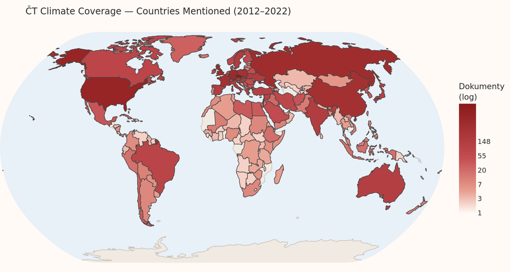

Počet dokumentů zmiňujících danou zemi (logaritmická škála, 2012–2022)

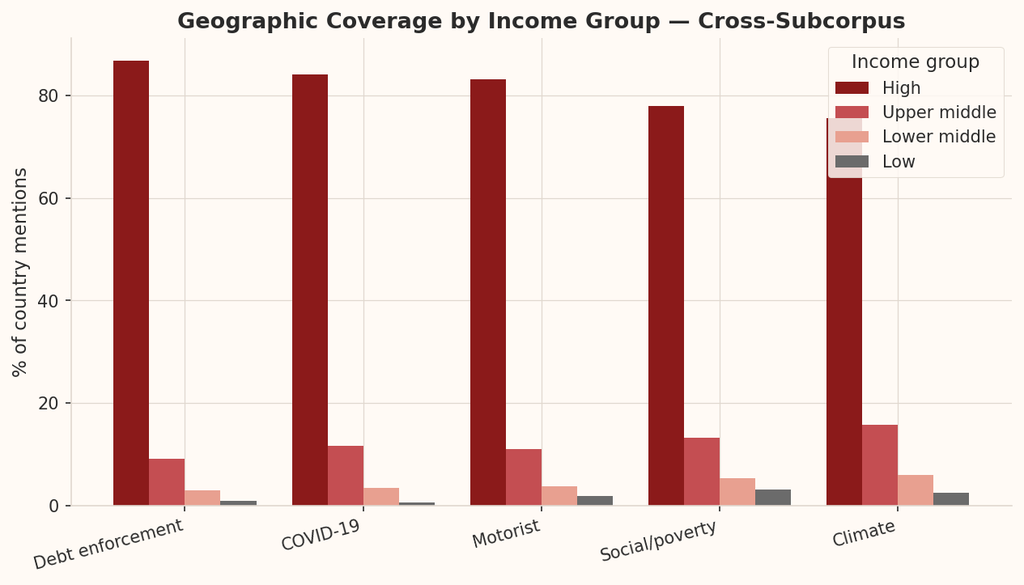

Podíl zmínek zemí dle příjmové skupiny napříč podkorpusy ČT

## Nalezení č. 2 — Objem: reaktivní, nikoli proaktivní

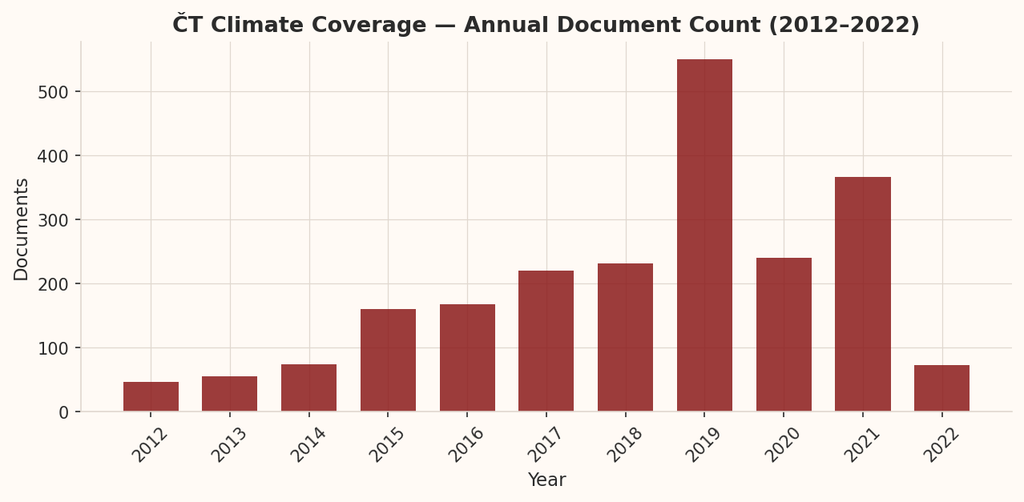

Roční počet klimatických dokumentů (2012–2022)

## Nalezení č. 3 — Mluvčí: elity dominují, občané na okraji

Z 56 613 zmínek mluvčích tvoří novináři/moderátoři (M1) 54,8 %, politici (M6) 22,6 %, zainteresované strany (M5) 11,0 %, vědci (M3) 8,6 % a **občané (M2) jen 2,0 %**. Pseudovědci (M4) jsou prakticky nepřítomní (0,2 % – 87 zmínek za 10 let).

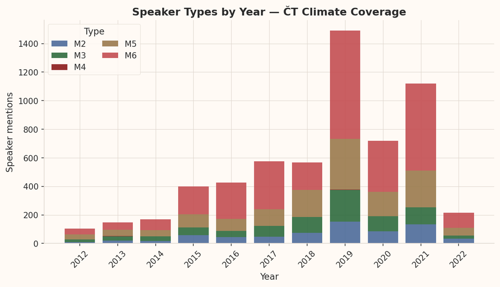

Typy mluvčích dle roku

**Klíčový závěr:** Vědci jsou v poměru 2,6:1 přečísleni politiky. Klima je pokryto primárně jako politické téma, nikoli vědecké. Žádný vědec (M3) nebyl nikdy klasifikován jako popírač (S1).

## Nalezení č. 4 — Gender: systematická mezera v expertních hlasech

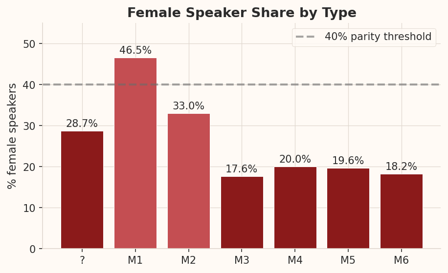

Podíl žen u jednotlivých typů mluvčích

## Nalezení č. 5 — Postoje: zodpovědné, nikoli transformativní

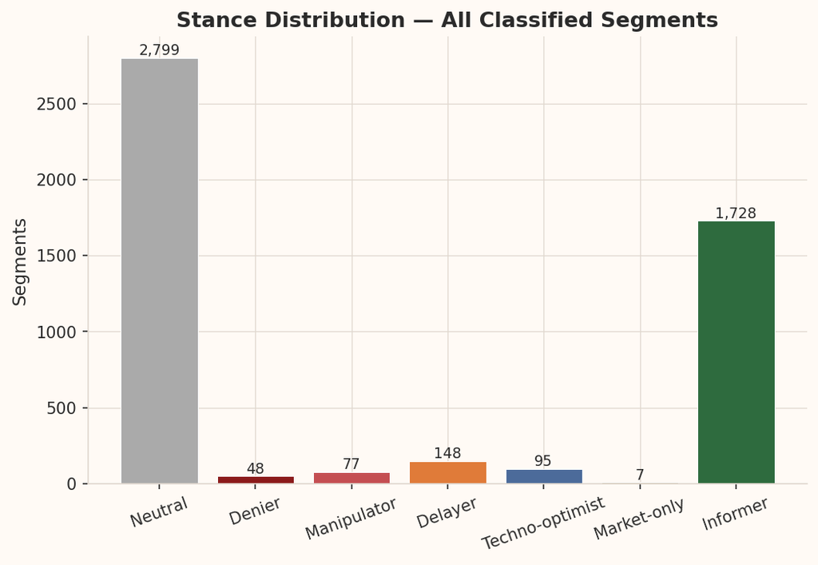

Distribuce stanovisek (všechny klasifikované segmenty)

**Klíčový závěr:** 10,2 % článků s nestranným postojem obsahuje současně problematický hlas (S1/S2/S3) a informátora (S6) – forma falešné rovnováhy. Spike v roce 2017 (18,6 %).

## Nalezení č. 6 — Urgentnost bez jednání

Krizový jazyk se více než zdvojnásobil (40 → 104 výskytů na 100 dokumentů, 2012→2022). Výzvy k jednání stagnovaly (10 → 12). Poměr klesl z 0,26 (2012) na 0,11 (2022).

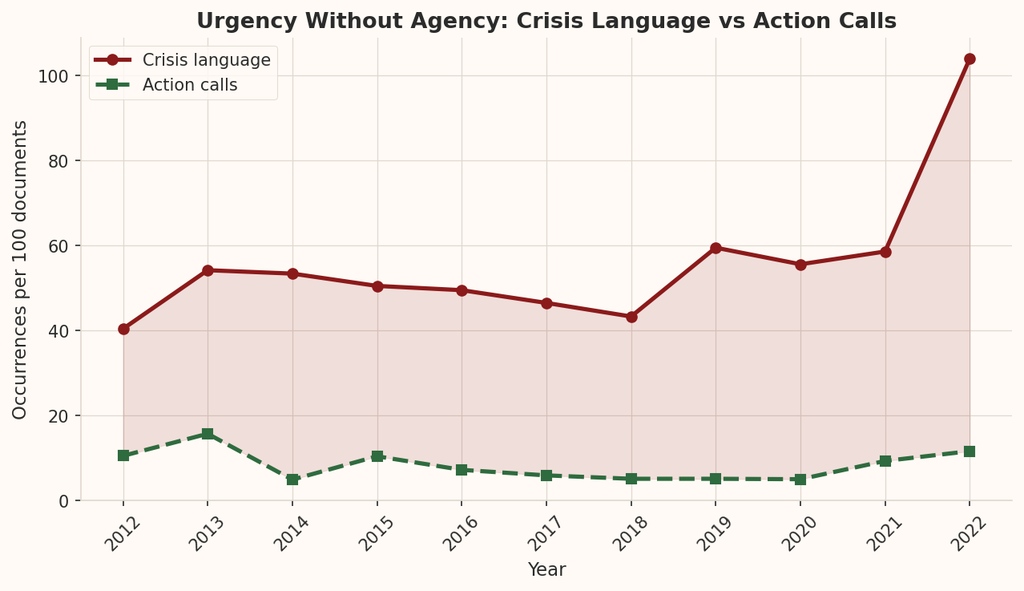

Krizový jazyk vs. výzvy k jednání (výskyty na 100 dokumentů)

**Klíčový závěr:** ČT komunikuje krizi, ale ne jednání. Klimatická spravedlnost je prakticky nepřítomná (méně než 2 výskyty na 100 dokumentů po celé sledované období).

## Nalezení č. 7 — Témata: geopolitika vytlačuje vědu

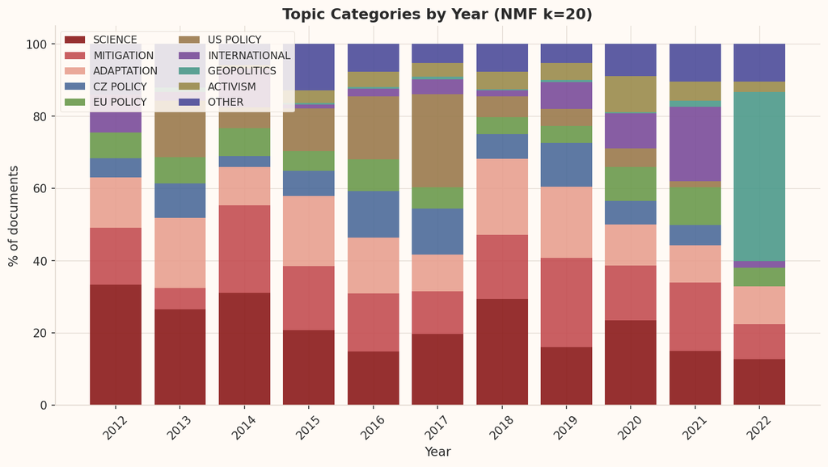

Kategorie témat dle roku (NMF k=20)

**Klíčový závěr:** Vědecky orientované pokrytí kleslo z 33 % (2012) na 13 % (2022). V roce 2022 obsadila geopolitika (Ukrajina/energie) 46,8 % klimatických dokumentů.

## Celkové hodnocení: transformativní žurnalistika

Tři kritéria transformativní žurnalistiky – de-polarizace, urgentnost a spravedlivá transformace – jsou hodnocena na škále 0–10 na základě 11 empirických indikátorů.

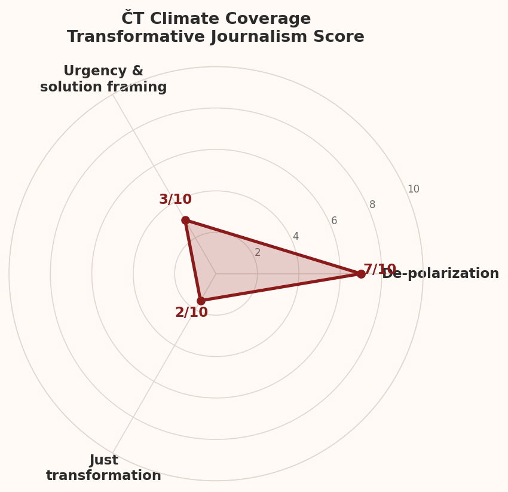

Hodnocení transformativní žurnalistiky (0–10)

[output not shown]

## Případové studie (P4)

### CS1: Jaderná energie a obnovitelné zdroje (88 dokumentů, 3,0 %)

Pokrytí je zarámováno jako energetická politika, nikoli klimatická věda. Politici dominují (221 z ~295 segmentů); vědci jen 5. Postoj "zpomalování" (S3) je zde nejvíce proporcionálně zastoupený ze všech tří případových studií. Debata o taxonomii EU (2022) strukturovala pokrytí kolem českého národního zájmu.

### CS2: Sucho a záplavy (586 dokumentů, 20,1 %)

Největší a nejdomestičtější případová studie. Vrchol v 2018–2019 odráží českou sucho/kůrovce krizi. Občané jsou nejvíce zastoupeni zde (172 segmentů). Klimatická atribuce přítomna, ale v pozadí; adaptace dominuje nad mitigací.

### CS3: Zdravotní dopady — ticho (17 dokumentů, 0,6 %)

**Klíčový závěr:** ČT pokrývá klima zodpovědně, ale ne transformativně. Vyhýbá se amplifikaci popírání a pseudovědy. Ale selhává ve všech dimenzích transformativní žurnalistiky: urgentnost bez řešení, marginalisation občanů a globálního jihu, genderová nerovnost a neviditelná klimatická spravedlnost.

## Metodologie

- **Korpus:** 531 593 přepisů zpravodajství ČT (2012–2022); klimatický podkorpus: 2 914 dokumentů
- **Extrakce mluvčích:** Regex + dvoustupňová klasifikace (pravidla + LLM Claude Haiku)
- **Klasifikace stanovisek (S0–S6):** Segmenty projevů mluvčích → LLM (Claude Haiku, 5 928 segmentů)
- **Tématické modelování:** NMF (sklearn), k=20, 5 000 vlastností TF-IDF; bez lemmatizace
- **Geografická detekce:** Tříprůchodový regex (tokeny, víceslovné fráze, adjektivní kmeny)
- **Genderová klasifikace:** Koncovka příjmení (-á → F) + korekce cizích mužských jmen